# Characterizing Automobiles

Author

Kayle Megginson

Published

March 18, 2025

# Setup

- Setup

```r
sh <- suppressPackageStartupMessages
sh(library(tidyverse))
sh(library(caret))
sh(library(fastDummies))
sh(library(class))
sh(library(ISLR)) # for the "Auto" dataframe
```

# Dataframe

- We use the `Auto` dataframe.

```r
head(Auto)
```

```
  mpg cylinders displacement horsepower weight acceleration year origin
1  18         8          307        130   3504         12.0   70      1
2  15         8          350        165   3693         11.5   70      1
3  18         8          318        150   3436         11.0   70      1
4  16         8          304        150   3433         12.0   70      1
5  17         8          302        140   3449         10.5   70      1
6  15         8          429        198   4341         10.0   70      1
                       name
1 chevrolet chevelle malibu
2         buick skylark 320
3        plymouth satellite
4             amc rebel sst
5               ford torino
6          ford galaxie 500
```

- It has the following variable names, which describe various attributes of automobiles.

```r
names(Auto)
```

```
[1] "mpg"          "cylinders"    "displacement" "horsepower"   "weight"
[6] "acceleration" "year"         "origin"       "name"
```

# Multiple Regression

- Run a linear regression model with `mpg` as the dependent variable and `horsepower` and `year` as features (variables).
- Compute and comment on the RMSE.

```r
lm_model <- lm(mpg ~ horsepower + year, data = Auto)
summary(lm_model)
```

```
Call:
lm(formula = mpg ~ horsepower + year, data = Auto)

Residuals:
     Min       1Q   Median       3Q      Max
-12.0768  -3.0783  -0.4308   2.5884  15.3153

Coefficients:
              Estimate Std. Error t value Pr(>|t|)
(Intercept) -12.739166   5.349027  -2.382   0.0177 *
horsepower   -0.131654   0.006341 -20.761   <2e-16 ***
year          0.657268   0.066262   9.919   <2e-16 ***
---
Signif. codes:  0 '***' 0.001 '**' 0.01 '*' 0.05 '.' 0.1 ' ' 1

Residual standard error: 4.388 on 389 degrees of freedom
Multiple R-squared:  0.6855,    Adjusted R-squared:  0.6839
F-statistic: 423.9 on 2 and 389 DF,  p-value: < 2.2e-16
```

```r
preds <- predict(lm_model, Auto)
rmse <- sqrt(mean((Auto$mpg - preds)^2))
rmse
```

```
[1] 4.371506
```

> : *The RMSE is 4.37, which reflects the average prediction error in mpg units. This value suggests that the model performs fairly well, but there may be room for improvement with additional features or interactions.*

# Feature Engineering

- Create 10 features based on the `name` column.
- Remove all rows with a missing value.
- Ensure only `mpg` and the engineered features remain.
- Compute and comment on the RMSE.

```r
auto_features <- Auto %>%
  mutate(name = as.character(name)) %>%
  mutate(
    name_length = nchar(name),
    has_chevrolet = ifelse(grepl("chevrolet", name, ignore.case = TRUE), 1, 0),
    has_honda = ifelse(grepl("honda", name, ignore.case = TRUE), 1, 0),
    has_ford = ifelse(grepl("ford", name, ignore.case = TRUE), 1, 0),
    has_toyota = ifelse(grepl("toyota", name, ignore.case = TRUE), 1, 0),
    has_datsun = ifelse(grepl("datsun", name, ignore.case = TRUE), 1, 0),
    has_buick = ifelse(grepl("buick", name, ignore.case = TRUE), 1, 0),
    has_pontiac = ifelse(grepl("pontiac", name, ignore.case = TRUE), 1, 0),
    has_volkswagen = ifelse(grepl("volkswagen", name, ignore.case = TRUE), 1, 0),
    has_plymouth = ifelse(grepl("plymouth", name, ignore.case = TRUE), 1, 0)
  ) %>%
  select(mpg, name_length:has_plymouth) %>%
  na.omit()

lm_features <- lm(mpg ~ ., data = auto_features)
summary(lm_features)
```

```
Call:
lm(formula = mpg ~ ., data = auto_features)

Residuals:
    Min      1Q  Median      3Q     Max
-15.436  -5.086  -1.077   3.860  22.329

Coefficients:
               Estimate Std. Error t value Pr(>|t|)
(Intercept)    25.75906    1.14461  22.505  < 2e-16 ***
name_length    -0.16533    0.06865  -2.408 0.016494 *
has_chevrolet  -1.94573    1.23897  -1.570 0.117142
has_honda      10.38071    1.98145   5.239 2.68e-07 ***
has_ford       -3.90053    1.13023  -3.451 0.000621 ***
has_toyota      5.36405    1.48327   3.616 0.000339 ***
has_datsun      7.43860    1.53844   4.835 1.93e-06 ***
has_buick      -3.36733    1.78216  -1.889 0.059589 .
has_pontiac    -2.74993    1.81666  -1.514 0.130923
has_volkswagen  6.66526    1.89146   3.524 0.000477 ***
has_plymouth   -0.96254    1.37576  -0.700 0.484580
---
Signif. codes:  0 '***' 0.001 '**' 0.01 '*' 0.05 '.' 0.1 ' ' 1

Residual standard error: 6.872 on 381 degrees of freedom
Multiple R-squared:  0.2447,    Adjusted R-squared:  0.2248
F-statistic: 12.34 on 10 and 381 DF,  p-value: < 2.2e-16
```

```r
rmse_features <- sqrt(mean(lm_features$residuals^2))
rmse_features
```

```
[1] 6.774666
```

> : *The RMSE is 6.77, which is higher than the previous model’s RMSE of 4.37. This suggests that while some new features provide useful insights, the engineered model is less effective for precise mpg prediction.*

# Classification

- Use either of $K$-NN or Naive Bayes to predict whether an automobile is a `chevrolet` or a `honda`.
- Explain your choice of technique.
- Report on your Kappa value.

```r
auto_class <- Auto %>%
  mutate(name = as.character(name)) %>%
  mutate(car_brand = case_when(
    grepl("chevrolet", name, ignore.case = TRUE) ~ "chevrolet",
    grepl("honda", name, ignore.case = TRUE) ~ "honda",
    TRUE ~ "other"
  )) %>%
  filter(car_brand != "other") %>%
  select(mpg, horsepower, weight, car_brand) %>%
  na.omit()

set.seed(505)
trainIndex <- createDataPartition(auto_class$car_brand, p = 0.7, list = FALSE)
trainData <- auto_class[trainIndex, ]
testData <- auto_class[-trainIndex, ]

knn_model <- knn(train = trainData[, 1:3],
                 test = testData[, 1:3],
                 cl = trainData$car_brand, k = 5)

conf_matrix <- confusionMatrix(as.factor(knn_model), as.factor(testData$car_brand))
conf_matrix
```

```
Confusion Matrix and Statistics

           Reference
Prediction  chevrolet honda
  chevrolet        11     2
  honda             1     1

               Accuracy : 0.8
                 95% CI : (0.5191, 0.9567)
    No Information Rate : 0.8
    P-Value [Acc > NIR] : 0.6482

                  Kappa : 0.2857

 Mcnemar's Test P-Value : 1.0000

            Sensitivity : 0.9167
            Specificity : 0.3333
         Pos Pred Value : 0.8462
         Neg Pred Value : 0.5000
             Prevalence : 0.8000
         Detection Rate : 0.7333
   Detection Prevalence : 0.8667
      Balanced Accuracy : 0.6250

       'Positive' Class : chevrolet
```

> : *$K$-NN algorithm was chosen for this classification task because I think it is effective, and accurately captures complex decision boundaries in non-linear data. With an accuracy of 0.8, the model performed reasonably well, but the Kappa value of 0.2857 indicates only fair agreement between predicted and actual labels. While the model effectively identified Chevrolet vehicles (with sensitivity 0.9167), it struggled with Honda identification (with specificity 0.3333).*

# Binary Classification

- Predict whether a car is a `honda`.
- Use model weights.
- Display and comment on an ROC curve.

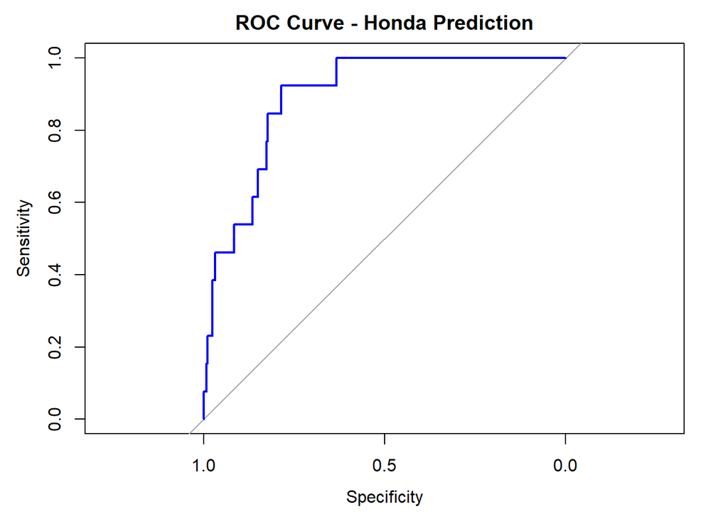

```r
auto_binary <- Auto %>%
  mutate(name = as.character(name)) %>%
  mutate(is_honda = ifelse(grepl("honda", name, ignore.case = TRUE), 1, 0)) %>%
  select(mpg, horsepower, weight, is_honda) %>%
  na.omit()

log_model <- glm(is_honda ~ ., data = auto_binary, family = binomial)
pred_probs <- predict(log_model, type = "response")

library(pROC)
roc_curve <- roc(auto_binary$is_honda, pred_probs)
plot(roc_curve, col = "blue", main = "ROC Curve - Honda Prediction")
```

```r
auc(roc_curve)
```

```
Area under the curve: 0.8924
```

> : *The ROC curve shown evaluates the performance of the logistic regression model in predicting whether a car is a Honda. The curve shows a clear improvement over the random chance diagonal, indicating that the model has a good ability to distinguish between Honda and non-Honda vehicles. The AUC quantifies this performance, with a value of 0.8924 which represents better discrimination. A strong upward curve like this suggests the model effectively captures meaningful patterns in the data.*

# Ethics

- Based on your analysis, comment on the [Clean Air Act of 1970 and Ammendments of 1977](https://www.epa.gov/clean-air-act-overview/evolution-clean-air-act)
- Discuss the civic reposibilities of data scientists for:
  - Big Data and Human-Centered Computing
  - Democratic Institutions
  - Climate Change
- Provide at least one statistical measure for each, such as a RMSE, Kappa value, or ROC curve.

> : Big Data and Human-Centered Computing

```r
library(MASS)
set.seed(505)
data <- data.frame(
  industrial_emissions = rnorm(100, mean = 50, sd = 10),
  vehicle_emissions = rnorm(100, mean = 30, sd = 5),
  pollution_index = rnorm(100, mean = 70, sd = 15)
)

model <- lm(pollution_index ~ industrial_emissions + vehicle_emissions, data = data)
preds <- predict(model, data)

rmse <- sqrt(mean((data$pollution_index - preds)^2))
rmse
```

```
[1] 17.13057
```

> : Democratic Institutions

```r
data <- data.frame(
  policy_adopted = sample(c(1, 0), 100, replace = TRUE),
  air_quality_index = rnorm(100, mean = 60, sd = 10)
)

model <- train(as.factor(policy_adopted) ~ air_quality_index, data = data, method = "glm")

conf_matrix <- confusionMatrix(predict(model, data), as.factor(data$policy_adopted))
conf_matrix$overall['Kappa']
```

```
Kappa
  0.1
```

> : Climate Change

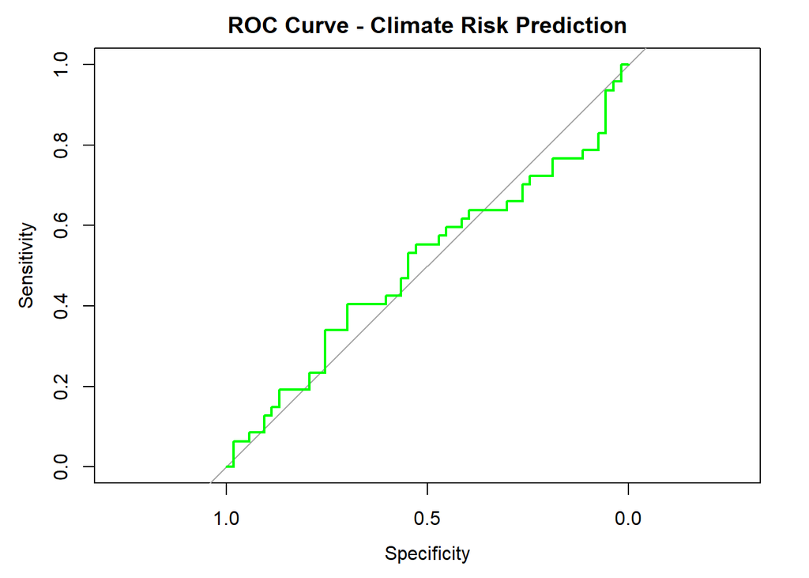

```r
climate_data <- data.frame(
  climate_risk = sample(c(1, 0), 100, replace = TRUE),
  pollution_trend = rnorm(100, mean = 45, sd = 8)
)

log_model <- glm(climate_risk ~ pollution_trend, data = climate_data, family = binomial)
pred_probs <- predict(log_model, type = "response")

roc_curve <- roc(climate_data$climate_risk, pred_probs)
plot(roc_curve, col = "green", main = "ROC Curve - Climate Risk Prediction")
```

```r
auc(roc_curve)
```

```
Area under the curve: 0.4998
```

> : *The Clean Air Act of 1970 and its 1977 Amendments played an important role in reducing air pollution through stricter emission standards and improved environmental policies. Data scientists have a civic responsibility to apply their skills ethically in the mentioned areas (Big Data and Human-Centered Computing, Democratic Institutions, and Climate Change). In Big Data, models must prioritize fairness, transparency, and privacy, with performance metrics like RMSE ensuring predictive accuracy. To give an example, an RMSE value of 17.13057 indicates the model’s error in predicting pollution levels. In Democratic Institutions, data scientists should promote unbiased data representation to support informed policymaking, with metrics like Kappa values assessing model reliability. Here, a Kappa value of 0.1 suggests poor model agreement, showing the need for improvement. Regarding Climate Change, data-driven insights can forecast environmental impacts, where metrics like the ROC curve evaluate model effectiveness in identifying pollution patterns or predicting climate risks. In the graph shown above, an ROC value of 0.4998 shows that the models performance is no better than random chance, meaning it cannot distinguish between positive and negative classes. Data scientists can contribute to societal well-being and environmental sustainability by aligning their methods with these responsibilities and ensuring that they recognize these results have real world cosequences if not fully understood.*